# BRCA_initial_variant_selection

Piotr Stomma

# What this file contains

This documment summarises initial selection of the variants of CliqueSimNet we found useful for gene coexpression networks analysis.

Considering different objective functions, thresholding and clique relaxation strategies, our initial test included testing all 48 variants:

- 2 initial thresholding strategies of $\mathbf{S}$: `complexity` vs. by `mst`
- 2 objective functions for finding thr. on clique similarity: `modularity` and `MSTDunn` index.
- 6 clique expansion methods: `basic`, `average`, `maxW`, `outW`, `outN` and additionally, here named `custom` (based on coloring of the complement graph of $G_{\mathbf{S}}$ and referred to as `unW` in the main manuscript)
- 2 clique expansion methods: `greedyCliqueJoin` and `components`,

Below code constructs a `data.frame` with all of the combinations listed. Row number gives the combination identifier number. In the end we tested 6 most viable combinations from the list below:

```r
expand.grid(
t_S=c("complexity", "mst"),
t_CS=c("modularity", "mst"),
expansion_mode=c("basic", "average", "max", "outN", "outW", "custom" ), #custom - coloring of complement graph without caring about weights(unW variant)
t_CS_relax_method=c("components", "greedyCliqueJoin"))-> param_df
cbind(ID=1:nrow(param_df) ,param_df)
```

```
##    ID        t_S       t_CS expansion_mode t_CS_relax_method
## 1   1 complexity modularity          basic        components
## 2   2        mst modularity          basic        components
## 3   3 complexity        mst          basic        components
## 4   4        mst        mst          basic        components
## 5   5 complexity modularity        average        components
## 6   6        mst modularity        average        components
## 7   7 complexity        mst        average        components
## 8   8        mst        mst        average        components
## 9   9 complexity modularity            max        components
## 10 10        mst modularity            max        components
## 11 11 complexity        mst            max        components
## 12 12        mst        mst            max        components
## 13 13 complexity modularity           outN        components
## 14 14        mst modularity           outN        components
```

[output cut: 34 more lines]

### Exclusion of ’mst` variant for initial similarity threshold search

Initial analysis revealed that `mst` method for similarity thr. search, as it stands, is not suitable for the problem as few, highly correlated genes in the network (but otherwise mildly correlated with the rest) skew the found threshold to a too extreme value:

```r
# load the BRCA dataset
readRDS("../gene_expr_data.rds")->X
# faster correlation computation (if OpenBLAS matrix mul backend is used):
library(matrixStats)
source("../cor_matmul.R")
similarity_matrix(fastPearsonData(X))-> S
library(cliqueClusteR) #load CliqueSimNet
critical_mst_thr(S)-> mst_thr
library(magrittr)
igraph::components(S %thr% mst_thr %>% igr_() )-> thr_S_comps
print("sizes of 5 biggest connected components of simil. graph thresholded by MST:")
```

```
## [1] "sizes of 5 biggest connected components of simil. graph thresholded by MST:"
```

```r
sort(thr_S_comps$csize, decr=TRUE)[1:5]
```

```
## [1] 2 1 1 1 1
```

```r
print("value of mst thr:")
```

```
## [1] "value of mst thr:"
```

```r
print(as.numeric(mst_thr))
```

```
## [1] 0.9593042
```

We see that the method separates 2 perfectly correlated genes from the rest of the network, which in itself might not be wrong, but without further iteration/refining makes it not usable for the task of initial thresholding.

This reduced the number of variants to test to 24.

### Selection of most balanced variants

For further analysis we focused on the remaining variants that produced most balanced solutions, to exclude the other uninteresting extreme of aggregating majority of genes to one big cluster.

(Note that code below will work as intended only if all of 48 variants were computed using `v1b_initial_algo_test.R`).

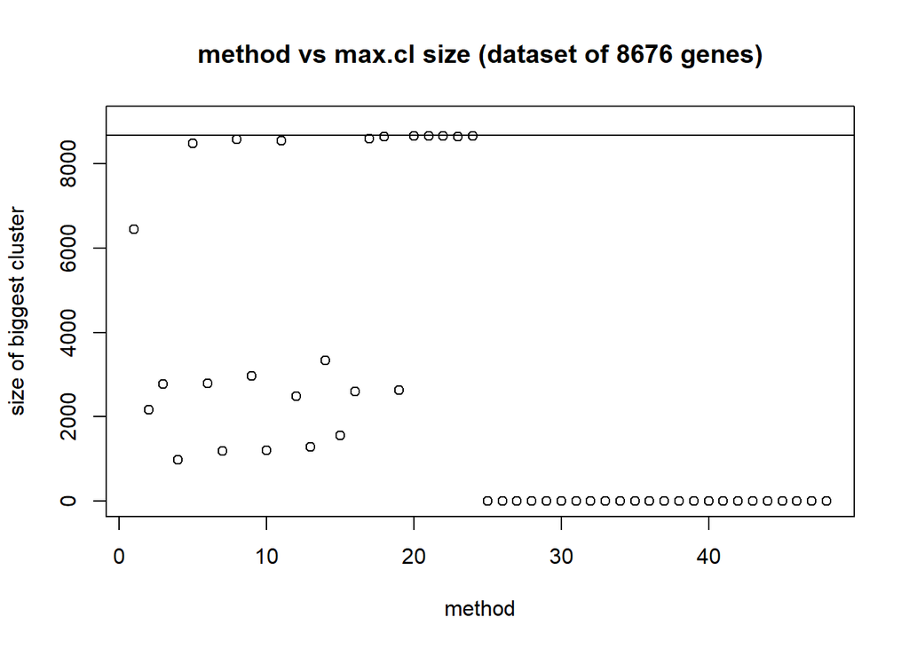

```r
#load precomputed cluster membership vectors, ARI similarities and combination
# data frame
lv<-readRDS("../devel_label_vecs.rds")
sm<-readRDS("../devel_method_similarity.rds")
df<-readRDS("../devel_method_runtime_df.rds")
sm_order<-order(colSums(sm))
smv<- sm[sm_order,sm_order] #visualization purposes
lapply(lv, function(x) max(table(x)))[sm_order] %>%
  unlist() -> max_cl
{plot(max_cl, xlab="method",
        ylab="size of biggest cluster",
        main="method vs max.cl size (dataset of 8676 genes)",
        ylim=c(0,9000))
abline(h=8676)}
```

Horizontal line at around 8600 shows the size of the dataset. We see that apart from extreme cases of `mst` method on the right, several methods basically put everything into one big component. Discounting those other extreme ones, almost all remaining variants are based on maximizing modularity and finding threshold on similarity by complexity method and differ mostly by `expansion_mode` (clique building strategy) and `relax_method` (clique joining method).

```r
viable_methods<-cbind(max_cl_size=unname(max_cl), df[sm_order,])
viable_methods<- viable_methods[ (viable_methods$max_cl_size>2) &
                                  (viable_methods$max_cl_size<8000),
]
viable_methods[,1:5]
```

```
##    max_cl_size        t_S       t_CS expansion_mode t_CS_relax_method
## 35        6439 complexity        mst            max  greedyCliqueJoin
## 21        2173 complexity modularity         custom        components
## 45        2767 complexity modularity         custom  greedyCliqueJoin
## 13         981 complexity modularity           outN        components
## 37        2785 complexity modularity           outN  greedyCliqueJoin
## 17        1191 complexity modularity           outW        components
## 25        2974 complexity modularity          basic  greedyCliqueJoin
## 5         1207 complexity modularity        average        components
## 41        2489 complexity modularity           outW  greedyCliqueJoin
## 1         1288 complexity modularity          basic        components
## 31        3340 complexity        mst        average  greedyCliqueJoin
## 9         1550 complexity modularity            max        components
## 33        2600 complexity modularity            max  greedyCliqueJoin
## 29        2636 complexity modularity        average  greedyCliqueJoin
```

### Representative variant selection from the rest

For the rest of the variants, we selected 6 most representative of the rest by considering pairwise similarities between clusterings measured by Adjusted Rand Index (ARI). Below code replaces names of the variants with shorter names, for the purposes of visualization.

```r
smv[(max_cl<8000) & (max_cl>2),
    (max_cl<8000) & (max_cl>2)]-> smv_viable
short_names<-stringr::str_replace(colnames(smv_viable),"t_S.","")
short_names<-stringr::str_replace(short_names,"t_CS.","")
short_names<-stringr::str_replace(short_names,"clq.","")
short_names<-stringr::str_replace(short_names,"alg.","")
short_names<-stringr::str_replace_all(short_names," ",".")
short_names<-stringr::str_replace_all(short_names,"\\.\\.",".")
short_names<-stringr::str_replace(short_names,"\\.","")
short_names<-stringr::str_replace(short_names,"complexity","c")
short_names<-stringr::str_replace(short_names,"modularity","mo")
short_names<-stringr::str_replace(short_names,"mst","ms")
short_names<-stringr::str_replace(short_names,"greedyCliqueJoin","g")
short_names<-stringr::str_replace(short_names,"components","c")
short_names<-stringr::str_replace(short_names,"max","m")
short_names<-stringr::str_replace(short_names,"basic","b")
short_names<-stringr::str_replace(short_names,"custom","c")
short_names<-stringr::str_replace(short_names,"average","a")
short_names<-stringr::str_replace(short_names,"outW","ow")
short_names<-stringr::str_replace(short_names,"outN","on")
short_names
```

```
##  [1] "c.ms.m.g"  "c.mo.c.c"  "c.mo.c.g"  "c.mo.on.c" "c.mo.on.g" "c.mo.ow.c"
##  [7] "c.mo.b.g"  "c.mo.a.c"  "c.mo.ow.g" "c.mo.b.c"  "c.ms.a.g"  "c.mo.m.c"
## [13] "c.mo.m.g"  "c.mo.a.g"
```

```r
colnames(smv_viable)<-rownames(smv_viable)<-short_names
```

Below visualization of the heatmap provides the rationale for the selection (requires additional package `gplots`).

Codes of the names are as follows:

- first letter: method of initial thresholding: `c` stands from `complexity` method
- second part: `mo` or `ms` – objective function used, `modularity` or `MSTDunn` index
- 3rd part: clique expansion strategy:
  - `basic` (`b`), `average`(`a`), `maxW`(`m`),`outW` (`ow`), `outN` (`on`), `custom` (`c`) (last one – based on greedy vertex coloring of complement graph, officially not part of the method, tested to check if including information on weights during the clique building process matters).
- last part: clique relaxation method: `g` for `greedy` method and `c` for `components`.

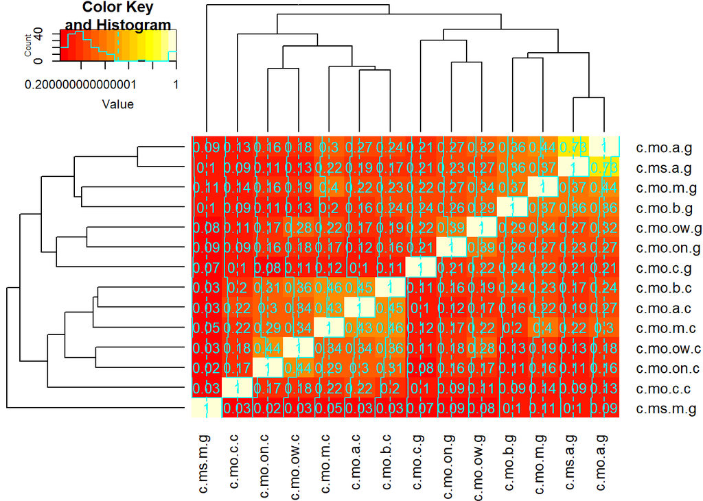

```r
if (require(gplots)) heatmap.2(smv_viable, cellnote = round(smv_viable,2))
```

To narrow down the test further, we defined 3 clusters of methods according to “ARI similarity”:

```r
methods_by_similarity= list(
              CS_components=c(  #methods based on joining by "components"
              "c.mo.on.c","c.mo.ow.c",
              "c.mo.m.c","c.mo.a.c",
              "c.mo.b.c"),
              greedyJoin_out=c("c.mo.on.g",    #clique relax. by "greedy"
                               "c.mo.ow.g"),   #clique building by considering
                                               #connections "external" to the
                                               #clique

                greedyJoin_in=c("c.mo.b.g",    #relax. by "greedy"
                              "c.mo.m.g",       #clique building by
                              "c.mo.a.g")   #aggregating connections"internally"
                      )
```

From `greedyJoin_out`, we have chosen outN because it was less similar to other methods from the two.

Below code chooses these variants and saves their information for further stability testing and comparisons with WGCNA (it is functionally equivalent to the script of `v1d_viable_method_selection.R`)

```r
representative_variants<-c("c.mo.c.c", "c.mo.c.g",
                           "c.mo.on.g",
                           "c.mo.m.g",
                           "c.mo.ow.c",
                           "c.mo.b.g")
```

```r
viable_subset_to_test_IDX<- match(representative_variants,
                                  colnames(smv_viable))

 to_test_df<- viable_methods[viable_subset_to_test_IDX,2:5]
saveRDS(to_test_df,"../vcl_clq_based_variants_to_test.rds")
clq_ref<- rep(NA, length(to_test_df)) %>% as.list()
result_string<- "../clusters_t_S=%s;t_CS=%s;mode=%s;join=%s.rds"
for (clq_i in 1:nrow(to_test_df)){
        t_S<- as.character(to_test_df$t_S[[clq_i]])
        t_CS<- as.character(to_test_df$t_CS[[clq_i]])
        t_CS_relax_method<- as.character(to_test_df$t_CS_relax_method[[clq_i]])
        expansion_mode= as.character(to_test_df$expansion_mode[[clq_i]])
        fname<-sprintf(result_string, t_S,t_CS,expansion_mode,t_CS_relax_method)
        clq_ref[[clq_i]] <- readRDS(fname)$cluster_membership$node
        }
saveRDS(clq_ref,"../clq_reference_modules.rds")
```